# Dance_competition_analysis

```python
import pandas as pd
df=pd.read_csv("Dance_competition_analysis.csv")
df
```

|  | First_name | Dance_style | Points | Yrs_practiced | Town | Age |
| --- | --- | --- | --- | --- | --- | --- |
| 0 | Riin | Rythmic_Dance | 20 | 12 | Tallinn | 20 |
| 1 | Mia | Rythmic_Dance | 7 | 3 | Tartu | 17 |
| 2 | Loretta | Rythmic_Dance | 10 | 5 | Pärnu | 15 |
| 3 | Maria | Hip-Hop | 10 | 7 | Pärnu | 10 |
| 4 | Laureen | Rythmic_Dance | 20 | 14 | Tallinn | 18 |
| 5 | Vanessa | Rythmic_Dance | 9 | 2 | Tallinn | 14 |
| 6 | Elizabeth | Hip-Hop | 5 | 1 | Tartu | 12 |
| 7 | Birgit | Hip-Hop | 20 | 6 | Tartu | 11 |
| 8 | Riselle | Rythmic_Dance | 10 | 4 | Tartu | 11 |
| 9 | Annabel | Rythmic_Dance | 11 | 4 | Tartu | 10 |
| 10 | Emilia | Rythmic_Dance | 9 | 2 | Tartu | 12 |
| 11 | Sille | Hip-Hop | 17 | 6 | Pärnu | 16 |
| 12 | Eleri | Hip-Hop | 17 | 8 | Pärnu | 17 |
| 13 | Hanna | Hip-Hop | 20 | 11 | Pärnu | 22 |
| 14 | Karola | Rythmic_Dance | 17 | 13 | Tallinn | 19 |
| 15 | Karoliina | Rythmic_Dance | 19 | 11 | Tallinn | 17 |
| 16 | Lisette | Hip-Hop | 17 | 13 | Tartu | 18 |
| 17 | Sandra | Hip-Hop | 15 | 8 | Pärnu | 16 |
| 18 | Jana | Hip-Hop | 16 | 10 | Tallinn | 15 |
| 19 | Annika | Rythmic_Dance | 8 | 4 | Tallinn | 14 |
| 20 | Helve | Rythmic_Dance | 14 | 7 | Tallinn | 14 |

Who has practiced the most?

```
<function matplotlib.pyplot.show(close=None, block=None)>
```

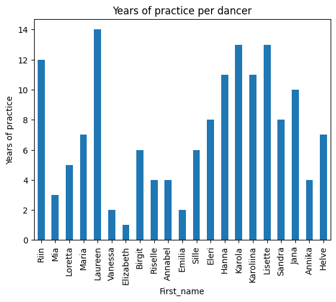

```python
import matplotlib.pyplot as plt


df.plot(kind="bar", x="First_name", y="Yrs_practiced", legend=False)
plt.ylabel("Years of practice")
plt.title("Years of practice per dancer")
plt.show
```

From the bar chart, we can see that Laureen has practiced the most years (14) and Elizabeth the least (1 yr).

Who gets highest scores at competitions?

```
<function matplotlib.pyplot.show(close=None, block=None)>
```

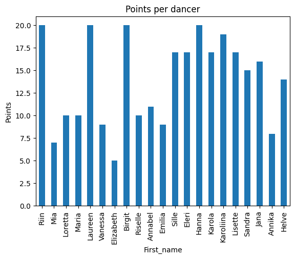

```python
import matplotlib.pyplot as plt


df.plot(kind="bar", x="First_name", y="Points", legend=False)
plt.ylabel("Points")
plt.title("Points per dancer")
plt.show
```

From this chart, we can see that Riin, Laureen, Birgit and Hanna got the highest (maximum) points, and Elizabeth got the lowest score.

Does more practicing result in better points?

```
<function matplotlib.pyplot.show(close=None, block=None)>
```

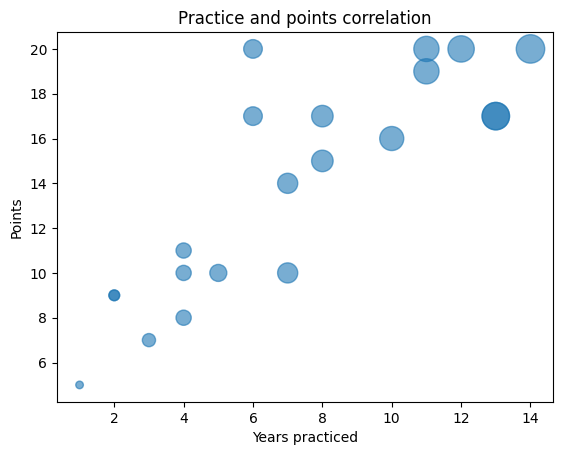

```python
plt.scatter(df["Yrs_practiced"], df["Points"], s=df["Yrs_practiced"]*30, alpha=0.6)
plt.xlabel("Years practiced")
plt.ylabel("Points")
plt.title("Practice and points correlation")
plt.show
```

The dots are mostly going upward from left to right, meaning a positive correlation, aka the more years a dancer has practiced, the more points they will get at a competition. There are, however, some outliers, for example, when dancers have practiced for 6 years, they have got 17 or 20 (max) points, and dancers who have practiced for 11-12 years can get better scores (max) than for 13 years practiced dancer (17p).

How do points differ per age?

```
<function matplotlib.pyplot.show(close=None, block=None)>
```

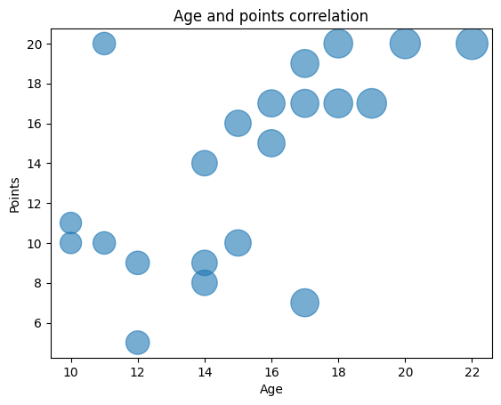

```python
plt.scatter(df["Age"], df["Points"], s=df["Age"]*30, alpha=0.6)
plt.xlabel("Age")
plt.ylabel("Points")
plt.title("Age and points correlation")
plt.show
```

From this chart, we can conclude that there is no obvious correlation between age and points. Younger dancers seem to be more in the bottom left corner, meaning they get lower points. And older dancers' points are more in the top right corner or in the middle top, meaning they get more points. But we can see many outliers, like 11-year-old who got 20p(max), or 17-year-old who got 7p. 16-20-year-olds seem to get almost the same points, meaning they could be at a very similar level.

Visualizing performance per student with a pie chart

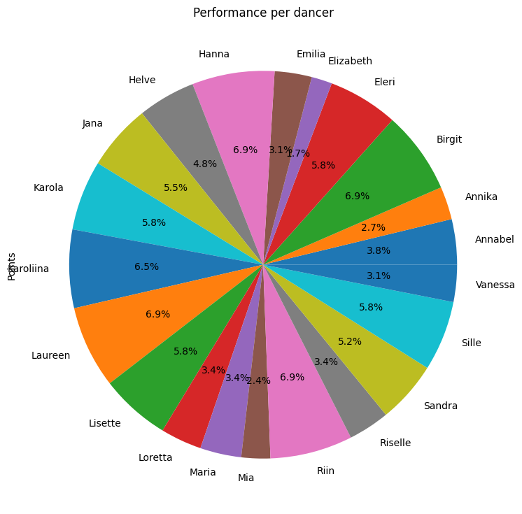

```python
avg_First_name=df.groupby ("First_name")["Points"]. mean ()
plt.figure(figsize=(9, 9))
avg_First_name.plot(kind="pie", autopct='%1.1f%%')
plt.title("Performance per dancer")
plt.show()
```

From the pie chart, we can see that Riin, Hanna, Laureen and Birgit got the most amount of points compared to others (6.9%). Elizabeth got 1.7% of points.

How do points and years of practice range?

```
Minimum years: 1 Q1: 4.0
```

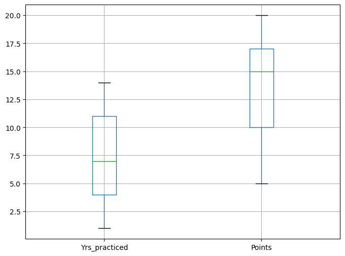

```python
years_min=df["Yrs_practiced"].min()
years_ql=df["Yrs_practiced"].quantile(0.25)
print("Minimum years:", years_min, "Q1:", years_ql)
plt.figure(figsize=(8,6))
df[["Yrs_practiced", "Points"]].boxplot()
plt.show()
```

From the box plot chart, we can see that there is quite a range in both points and years practiced. The range of years is 13 from 1 to 14 years of practice, the average lies between 4 to 11. A little more of range is among points, which differ from 5p to 20p, and average points lie between 10 and 17.